# Homework 2

Bob Bartolini

9/18/2020

Sampling and Iteration in the Tidyverse!

https://github.com/rjmaitri/Homework-2.git

## 1. Some Data with Flippers

#### 1a. Load the library palmerpenguins after installing it.

```r
#table package
library(reactable)
library(RColorBrewer)
#load the palmerpenguins package
library(palmerpenguins)
```

#### 1b. Show the head of the dataset penguins

```r
#apply the head function to the penguins dataset
head(penguins)
```

| species | island | bill_length_mm | bill_depth_mm | flipper_length_mm | body_mass_g | sex | year |
| --- | --- | --- | --- | --- | --- | --- | --- |
| Adelie | Torgersen | 39.1 | 18.7 | 181 | 3750 | male | 2007 |
| Adelie | Torgersen | 39.5 | 17.4 | 186 | 3800 | female | 2007 |
| Adelie | Torgersen | 40.3 | 18.0 | 195 | 3250 | female | 2007 |
| Adelie | Torgersen | NA | NA | NA | NA | NA | 2007 |
| Adelie | Torgersen | 36.7 | 19.3 | 193 | 3450 | female | 2007 |
| Adelie | Torgersen | 39.3 | 20.6 | 190 | 3650 | male | 2007 |

#### 1c. What do you learn by using str() and summary() on penguins()

```r
#apply str functin to penguins
str(penguins)
```

```
## tibble [344 x 8] (S3: tbl_df/tbl/data.frame)
##  $ species          : Factor w/ 3 levels "Adelie","Chinstrap",..: 1 1 1 1 1 1 1 1 1 1 ...
##  $ island           : Factor w/ 3 levels "Biscoe","Dream",..: 3 3 3 3 3 3 3 3 3 3 ...
##  $ bill_length_mm   : num [1:344] 39.1 39.5 40.3 NA 36.7 39.3 38.9 39.2 34.1 42 ...
##  $ bill_depth_mm    : num [1:344] 18.7 17.4 18 NA 19.3 20.6 17.8 19.6 18.1 20.2 ...
##  $ flipper_length_mm: int [1:344] 181 186 195 NA 193 190 181 195 193 190 ...
##  $ body_mass_g      : int [1:344] 3750 3800 3250 NA 3450 3650 3625 4675 3475 4250 ...
##  $ sex              : Factor w/ 2 levels "female","male": 2 1 1 NA 1 2 1 2 NA NA ...
##  $ year             : int [1:344] 2007 2007 2007 2007 2007 2007 2007 2007 2007 2007 ...
```

Str(penguins) gives a look into the structure of the dataframe “penguins”. We can see that this dataframe has 8 columns, with specie, time, location, sex and morphological data for a sample population of 344.

```r
#apply summary function to penguins
summary(penguins)
```

```
##       species          island    bill_length_mm
##  Adelie   :152   Biscoe   :168   Min.   :32.10
##  Chinstrap: 68   Dream    :124   1st Qu.:39.23
##  Gentoo   :124   Torgersen: 52   Median :44.45
##                                  Mean   :43.92
##                                  3rd Qu.:48.50
##                                  Max.   :59.60
##                                  NA's   :2
##  bill_depth_mm   flipper_length_mm  body_mass_g
##  Min.   :13.10   Min.   :172.0     Min.   :2700
##  1st Qu.:15.60   1st Qu.:190.0     1st Qu.:3550
##  Median :17.30   Median :197.0     Median :4050
##  Mean   :17.15   Mean   :200.9     Mean   :4202
##  3rd Qu.:18.70   3rd Qu.:213.0     3rd Qu.:4750
##  Max.   :21.50   Max.   :231.0     Max.   :6300
##  NA's   :2       NA's   :2         NA's   :2
##      sex           year
##  female:165   Min.   :2007
##  male  :168   1st Qu.:2007
##  NA's  : 11   Median :2008
##               Mean   :2008
##               3rd Qu.:2009
##               Max.   :2009
##
```

Summary(penguins) gives us a statistical summary of the penguins dataset. We can see the distribution of species, islands and morphological data summarised in a single table. The year and morphological data is presentend as min/max and quartiles, while the specie and island data is presented as counts.

#### 1d. What are the quantiles of bill depth across the whole data set? What do those quantiles mean?

```r
#summarize statistics of penguin bill depth

summary(penguins$bill_depth_mm)
```

```
##    Min. 1st Qu.  Median    Mean 3rd Qu.    Max.    NA's
##   13.10   15.60   17.30   17.15   18.70   21.50       2
```

The minimum bill depth recorded was 13.10. 25% of the samples were <=15.60mm; 50% were <=17.30mm; 75% were <=18.70mm and 100% were <= 21.50mm. The mean bill depth is 17.15mm. 2 bills were logged as NA’s.

## 2. What’s here? Let’s use dplyr!

```r
#load the dplyr library
library(dplyr)
```

#### 2a. If I have a vector, c(1,4,7,NA,9), what is its mean? Note, the NA is going to cause a problem. Look at ?mean to learn how to solve it.

```r
#apply the mean function with NA's removed

mean(c(1,4,7,NA,9),
     na.rm=TRUE)
```

```
## [1] 5.25
```

The mean of the vector is *5.25*. This required the mean function argument “na.rm” to work.

#### 2b. What is the mean, sd, and median of body mass across the data set? Note, these NAs are going to cause some problems, so you might need to look at the documentation for the relevant functions.

```r
#find mean of body mass from penguins data

mean(penguins$body_mass_g,
     na.rm=TRUE)
```

```
## [1] 4201.754
```

The mean of body mass of the palmer penguin dataset is 4201.754 grams.

```r
#find standard deviation of body mass from penguins data

sd(penguins$body_mass_g,
   na.rm=TRUE)
```

```
## [1] 801.9545
```

The standard deviation of body mass of the palmer penguin dataset is 801.9545 grams.

```r
#find median of body mass from penguins data

median(penguins$body_mass_g, na.rm=TRUE)
```

```
## [1] 4050
```

The median of body mass of the palmer penguin dataset is 4050 grams.

#### 2c. Repeat 2b, but, show us how these quantities differ by species

```r
#create an object
species_body_mass_mean <- penguins %>%
#group by species
  group_by(species) %>%
#summarize mean
  summarize(species_mean = mean(body_mass_g, na.rm = TRUE))

species_body_mass_mean
```

| species | species_mean |
| --- | --- |
| Adelie | 3700.662 |
| Chinstrap | 3733.088 |
| Gentoo | 5076.016 |

The Gentoo penguin is largest of the three species, with Adelie and Chinstrap penguins being approximately the same size.

```r
#create an object
species_body_mass_sd <- penguins %>%
#group by species
  group_by(species) %>%
#summarize std dev
  summarize(species_sd = sd(body_mass_g, na.rm = TRUE))

species_body_mass_sd
```

| species | species_sd |
| --- | --- |
| Adelie | 458.5661 |
| Chinstrap | 384.3351 |
| Gentoo | 504.1162 |

68% of each species is distributed around the mean by the standard deviation values in this table.

```r
#create object
species_body_mass_median <- penguins %>%
#group by species
    group_by(species) %>%
#summarize median
  summarize(species_median = median(body_mass_g, na.rm = TRUE))

species_body_mass_median
```

| species | species_median |
| --- | --- |
| Adelie | 3700 |
| Chinstrap | 3700 |
| Gentoo | 5000 |

The middle value of the distribution for each species is displayed here.

#### 2d. Repeat 2c, but just for Biscoe island. What is different in the results?

```r
#create object
species_body_mass_mean_biscoe <- penguins %>%
#filter by Bisco
  filter(island == "Biscoe") %>%
#group by species
  group_by(species) %>%
#summarize mean
  summarize(species_mean = mean(body_mass_g, na.rm = TRUE))

species_body_mass_mean_biscoe
```

| species | species_mean |
| --- | --- |
| Adelie | 3709.659 |
| Gentoo | 5076.016 |

```r
#create object
species_body_mass_sd_biscoe <- penguins %>%
#filter by Bisco
  filter(island == "Biscoe") %>%
#group by species
  group_by(species) %>%
#summarize sd
  summarize(species_sd = sd(body_mass_g, na.rm = TRUE))

species_body_mass_sd_biscoe
```

| species | species_sd |
| --- | --- |
| Adelie | 487.7337 |
| Gentoo | 504.1162 |

Biscoe also has a larger standard deviation than the entire data set.

```r
#create object
species_body_mass_sd_median <- penguins %>%
#filter by Bisco
  filter(island == "Biscoe") %>%
#group by species
  group_by(species) %>%
#summarize median
  summarize(species_median = median(body_mass_g, na.rm = TRUE))

species_body_mass_sd_median
```

| species | species_median |
| --- | --- |
| Adelie | 3750 |
| Gentoo | 5000 |

Biscoe also has a larger median than the entire data set.

#### 2E Make a species-island column in penguins using paste(). This is an awesome function that takes multiple strings, and slams them together using the argument sep = to define how the string should be combined. Try out paste(“Hello”, “Goodbye”, sep = “!”) to see how it works. Have the two be separated by _.

```r
#concantenate species and island columns
penguins$Species_Island <- paste(penguins$species, penguins$island, sep = "_")

penguins$Species_Island
```

```
##   [1] "Adelie_Torgersen" "Adelie_Torgersen"
##   [3] "Adelie_Torgersen" "Adelie_Torgersen"
##   [5] "Adelie_Torgersen" "Adelie_Torgersen"
##   [7] "Adelie_Torgersen" "Adelie_Torgersen"
##   [9] "Adelie_Torgersen" "Adelie_Torgersen"
##  [11] "Adelie_Torgersen" "Adelie_Torgersen"
##  [13] "Adelie_Torgersen" "Adelie_Torgersen"
##  [15] "Adelie_Torgersen" "Adelie_Torgersen"
##  [17] "Adelie_Torgersen" "Adelie_Torgersen"
##  [19] "Adelie_Torgersen" "Adelie_Torgersen"
##  [21] "Adelie_Biscoe"    "Adelie_Biscoe"
##  [23] "Adelie_Biscoe"    "Adelie_Biscoe"
##  [25] "Adelie_Biscoe"    "Adelie_Biscoe"
##  [27] "Adelie_Biscoe"    "Adelie_Biscoe"
##  [29] "Adelie_Biscoe"    "Adelie_Biscoe"
```

[output cut: 157 more lines]

The paste function concantenated string vectors, which was amended to the data frame.

## 3. A Little Light Plotting

#### 3a. Show the distribution of flipper_length_mm by species and island using boxplots. For one point of extra credit, redo creating the species_island column with the sep as instead of _. What does do? You will find it very handy in the future.

```r
#replace "_" with "\n"
penguins$Species_Island <- paste(penguins$species, penguins$island, sep = "\n")
```

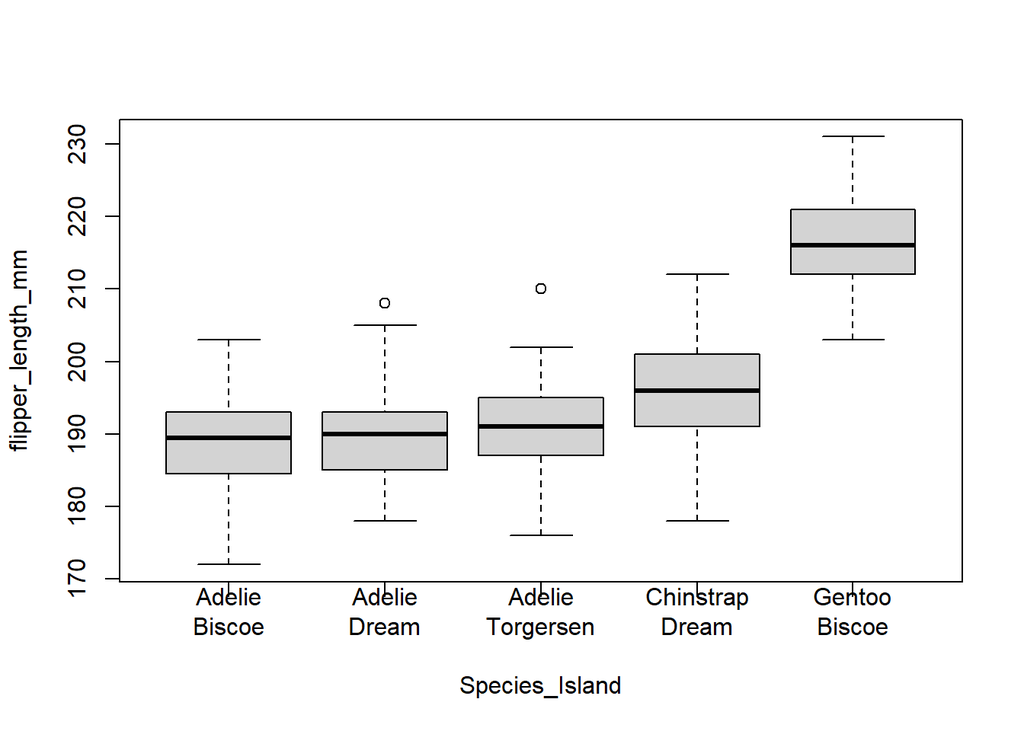

```r
#create a boxplot of flipper length by species_island
penguins %>%
boxplot(flipper_length_mm ~ Species_Island, data = .)
```

The boxplot displays the quartiles, medians and outliers for the species as they are on each island. Adelie are the smallest breed, Gentoo the largest.

#### 3b. Show the relationship between average flipper length and average body mass by species and island. What do you see?

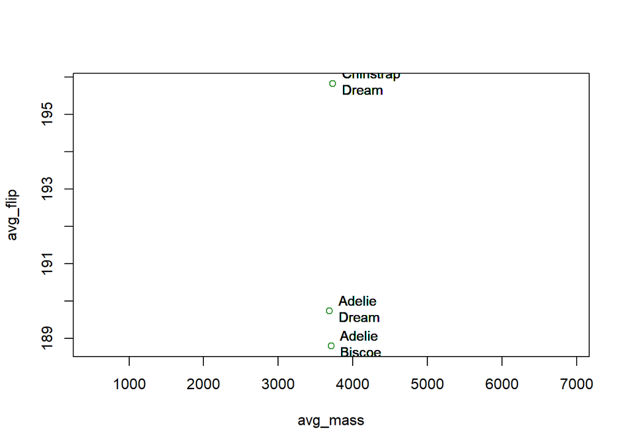

```
## integer(0)
```

```r
avg_mass_flip <- penguins %>%
  group_by(species, island) %>%
  mutate(avg_flip = mean(flipper_length_mm),
         avg_mass = mean(body_mass_g))

plot(avg_flip ~ avg_mass, data = avg_mass_flip, col = "forestgreen", asp = 500)+
text(avg_flip ~ avg_mass, labels=Species_Island,data=avg_mass_flip, cex=0.9, font=1, pos = 4)
```

The Adelie penguins are more rotund on Biscoe than Dream island and Chinstraps are morphologically distinct from the Adelie by a larger flipper length:body mass ratio.

#### 3c. Interesting. What if you had made the same plot with the whole dataset? What do you see? Is there anything that could clarify the result any more? Think about it - lots of possible right answers here.

[figure not shown]

```r
#make the plot colored by specie-island

palette <-  brewer.pal(5, "Dark2")

specie_col <- palette[factor(penguins$Species_Island)]

plot(flipper_length_mm ~ body_mass_g, data = penguins, col = specie_col)
legend("bottomright", legend = c("Adelie Torgersen", "Adelie Dream", "Chinestrap Dream", "Adelie Biscoe", "Gentoo Biscoe"), fill = palette)
```

```r
#  legend("bottomright", col = col(5, "Dark2"), c("Adelie Torgersen", "Adelie Dream", "Chinestrap Dream", "Adelie Biscoe", "Gentoo Biscoe"), pch = c("Adelie Torgersen", "Adelie Dream", "Chinestrap Dream", "Adelie Biscoe", "Gentoo Biscoe"))
```

## 4. Let’s get ready to simulate

#### 4a. Grab the values for bill_length_mm for Gentoo penguins in Biscoe Island and put it into an object. Note, the dplyr function pull() is kinda cool, as if you apply it to a data frame, it will pull out a vector from a column of interest. Try 21, 21, 22.8, 21.4, 18.7, 18.1, 14.3, 24.4, 22.8, 19.2, 17.8, 16.4, 17.3, 15.2, 10.4, 10.4, 14.7, 32.4, 30.4, 33.9, 21.5, 15.5, 15.2, 13.3, 19.2, 27.3, 26, 30.4, 15.8, 19.7, 15, 21.4. Kinda cool. Might help you here.

```r
#create object for bill length of gentoo from bisco
gent_biscoe_bill <- na.omit(penguins) %>%
  filter(species == "Gentoo" & island == "Biscoe") %>%
  pull(bill_length_mm)

gent_biscoe_bill
```

```
##   [1] 46.1 50.0 48.7 50.0 47.6 46.5 45.4 46.7 43.3 46.8 40.9
##  [12] 49.0 45.5 48.4 45.8 49.3 42.0 49.2 46.2 48.7 50.2 45.1
##  [23] 46.5 46.3 42.9 46.1 47.8 48.2 50.0 47.3 42.8 45.1 59.6
##  [34] 49.1 48.4 42.6 44.4 44.0 48.7 42.7 49.6 45.3 49.6 50.5
##  [45] 43.6 45.5 50.5 44.9 45.2 46.6 48.5 45.1 50.1 46.5 45.0
##  [56] 43.8 45.5 43.2 50.4 45.3 46.2 45.7 54.3 45.8 49.8 49.5
##  [67] 43.5 50.7 47.7 46.4 48.2 46.5 46.4 48.6 47.5 51.1 45.2
##  [78] 45.2 49.1 52.5 47.4 50.0 44.9 50.8 43.4 51.3 47.5 52.1
##  [89] 47.5 52.2 45.5 49.5 44.5 50.8 49.4 46.9 48.4 51.1 48.5
## [100] 55.9 47.2 49.1 46.8 41.7 53.4 43.3 48.1 50.5 49.8 43.5
## [111] 51.5 46.2 55.1 48.8 47.2 46.8 50.4 45.2 49.9
```

Wrangled the Gentoo Biscoe Bill length from the data.

#### 4b. Use replicate() to calculate the standard error of the mean 10 times. Use a formula! Don’t forget that NA values shouldn’t be included!

```r
#bootstrap the means
gentoo_bill_se_mean <- replicate(10,
                      sample(na.omit(gent_biscoe_bill),
                             size = length(gent_biscoe_bill),
                             replace = TRUE) %>% mean)
gentoo_bill_se_mean
```

```
##  [1] 47.38235 47.32941 47.75546 48.06218 47.60504 47.50588
##  [7] 46.96975 47.83193 46.97059 48.22941
```

The mean was calculated 10 times with sampling and replacement.

```r
#calculate SE
sd(c(gentoo_bill_se_mean))/sqrt(c(gentoo_bill_se_mean))
```

```
##  [1] 0.06121071 0.06124493 0.06097112 0.06077626 0.06106737
##  [6] 0.06113107 0.06147897 0.06092236 0.06147842 0.06067080
```

The standard error of the mean calculated ten times has a narrow range.

#### 4c. Use map_df() to create a data frame with the mean and sd of different sample sizes using the first 5 through 100 values (so, n = 5:100 - smallest sample size will have the values 1-5). Make sure the sample size is included in the final data frame.

```r
library(purrr)
#sample and replace the first five through 100 of the Bill data
gentdf <- map_df(5:100,
            ~data.frame(sample_size = .x,
                     samp_mean =  mean(gent_biscoe_bill[5:.x]),
                               samp_sd =  sd(gent_biscoe_bill[5:.x])))
reactable(gentdf)
```

| sample_size | samp_mean | samp_sd |
| --- | --- | --- |
| 5 | 47.6 | NA |
| 6 | 47.05 | 0.777817459305203 |
| 7 | 46.5 | 1.1 |
| 8 | 46.55 | 0.903696114115065 |
| 9 | 45.9 | 1.65075740192192 |
| 10 | 46.05 | 1.5215124054703 |
| 11 | 45.3142857142857 | 2.39125390498275 |
| 12 | 45.775 | 2.56890749430292 |
| 13 | 45.7444444444444 | 2.40474068826096 |
| 14 | 46.01 | 2.41773539587037 |

[output cut: 86 more lines]

#### 4d. Plot the relationship between sample size and SD and sample size versus SE of the mean. What difference do you see and why? Note, you’ll need to create a column for SE here!

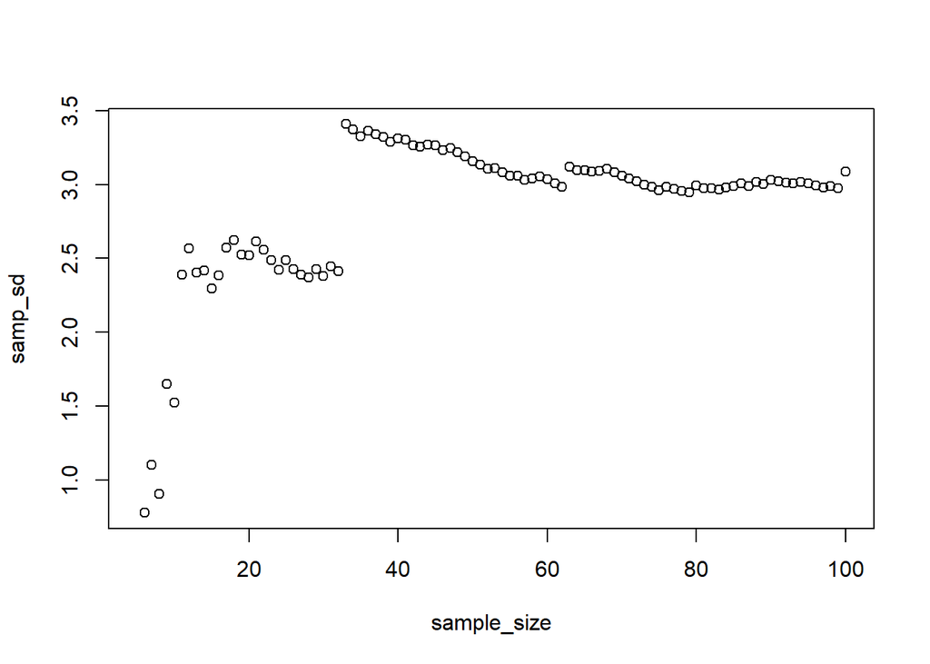

```r
#Plot relationship between sample size and SD
plot(~sample_size + samp_sd,  data = gentdf)
```

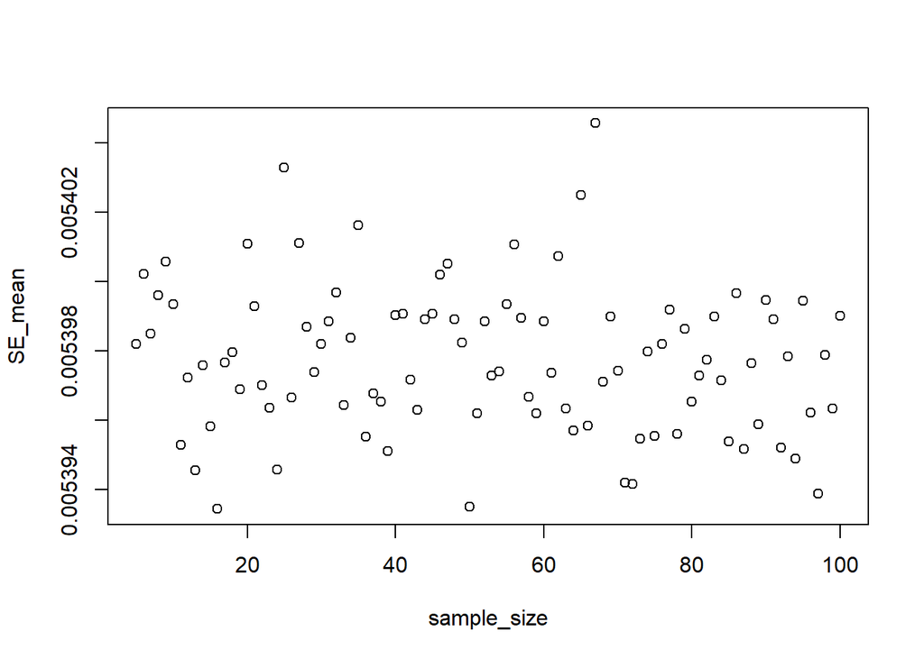

```r
#Bootstrap the SE of the means
gentoo_bill_ster_mean <- replicate(96,
                      sample((gentdf$samp_mean),
                             size = length(gentdf$samp_mean),
                             replace = TRUE) %>% mean)

#Create a column for SE
gentdf$SE_mean <- sd(c(gentoo_bill_ster_mean))/sqrt(c(gentoo_bill_ster_mean))

#plot samp_size vs. SE of the mean

plot(~sample_size + SE_mean, data = gentdf)
```

The plot depicts a SE of mean which is relatively stable across the sample sizes.

Extra Credit. Making beautiful tables is hard. There are a number of good packages to help you do that - and they were recently featured in this excellent article - https://rfortherestofus.com/2019/11/how-to-make-beautiful-tables-in-r/. Make a beautiful table showing the average properties of bills of penguins by species, sex, and island. Use whatever package you like. A basic nice table is worth 4 points. +1 for every additional bit of information you can convey with the table other than a nicely formatted table. Please explain what you have done to get each point. +1 for naturally incorporating each additional piece of information about properties beyond means. How visually appealing can you make this?

```r
#create object
AVGssi <- penguins %>%
#group by species
  group_by(species, island, sex) %>%
#summarize median
  summarize(flipper_mean = mean(flipper_length_mm, na.rm = TRUE),
            bill_length_mean = mean(bill_length_mm, na.rm = TRUE),
            bill_depth_mean = mean(bill_depth_mm, na.rm = TRUE),
            body_mass_mean = mean(body_mass_g, na.rm = TRUE))

#apply function reactable to AVGssi df
reactable(AVGssi)
```

| species | island | sex | flipper_mean | bill_length_mean | bill_depth_mean | body_mass_mean |
| --- | --- | --- | --- | --- | --- | --- |
| Adelie | Biscoe | female | 187.181818181818 | 37.3590909090909 | 17.7045454545455 | 3369.31818181818 |
| Adelie | Biscoe | male | 190.409090909091 | 40.5909090909091 | 19.0363636363636 | 4050 |
| Adelie | Dream | female | 187.851851851852 | 36.9111111111111 | 17.6185185185185 | 3344.44444444444 |
| Adelie | Dream | male | 191.928571428571 | 40.0714285714286 | 18.8392857142857 | 4045.53571428571 |
| Adelie | Dream | NA | 179 | 37.5 | 18.9 | 2975 |
| Adelie | Torgersen | female | 188.291666666667 | 37.5541666666667 | 17.55 | 3395.83333333333 |
| Adelie | Torgersen | male | 194.913043478261 | 40.5869565217391 | 19.3913043478261 | 4034.78260869565 |
| Adelie | Torgersen | NA | 187.25 | 37.925 | 18.175 | 3681.25 |
| Chinstrap | Dream | female | 191.735294117647 | 46.5735294117647 | 17.5882352941176 | 3527.20588235294 |
| Chinstrap | Dream | male | 199.911764705882 | 51.0941176470588 | 19.2529411764706 | 3938.97058823529 |

[output cut: 3 more lines]

https://github.com/rjmaitri/Homework-2.git